# Et si Einstein avait été aveugle

Derrière cette étrange question se trouve une vraie interrogation sur la nature de la matière. Quelle conclusion si on vivait dans un monde d’ondes sonores au lieu d’ondes lumineuses ❓

Si nous étions des ondes sonores conscientes, arriverions nous à la conclusion que rien ne peut aller plus vite que la vitesse du son (soit environ 340 m/s dans l’air) ?

Si nous étions des ondes sonores conscientes, notre existence serait cautionnée par ce fait. Si onde consciente on entendait l’impact d’une particule, Qu’entendrait-on ? Une onde sonore se créer, se déplacer, sans qu’aucune chose existante dans notre monde d’onde sonore ne puisse allez plus vite que la vitesse du son ?

Dans notre monde de lumière, un avion peut allez plus vite que la vitesse du son et provoquer un bang supersonique, n’en serait-il pas de même pour notre monde de lumière. Est-ce que quelque chose de nature différente ne pourrait pas aller au-delà de la vitesse de la lumière provoquant un bang luminique ? Cette dualité onde-corpuscule ne serait-ce pas cela, une particule que l’on lâche allant en fait au-delà de la vitesse de la lumière provoquant un bang luminique et ne laissant observable que la trace laissée par celui-ci, c’est à dire une onde ? Tout comme l’avion est la particule pour l’onde sonore consciente, l’onde générée par le franchissement du mur du son est sa trace laissée dans l’espace du son.

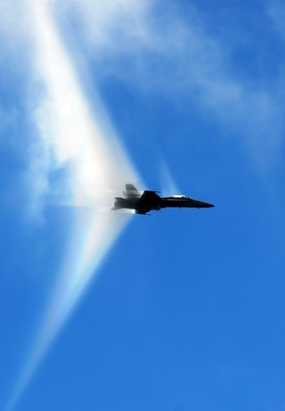

Ainsi je vois les particules comme des avions a réaction prêt a dépasser le mur du son qui une fois lâchées provoques un bang luminique laissant comme trace une onde.

C’est la dualité onde-corpuscule 🤔

Récapitulons, les particules sont de nature différente de ce que l'on connait (comme l'avion pour une onde sononore consciente qui est de nature complétement différente d'une onde sonore) qui vont à une vitesse supérieure à la vitesse de la lumière. Ce dépassement de vitesse laisse une trace, une onde, élément observable dans notre espace temps. Reste à voir comment s'articule les autres observations et étrangetés de la mécanique quantique avec ce postulat de base, à suivre.